# (Ford Gobike Data Exploration)

## by (Ali Hassan Sobh)

## Investigation Overview

> In this investigation, I wanted to look at bike ride trends on focusing on trip duration .

## Dataset Overview

> This data set includes information about individual rides made in a bike-sharing system covering the greater San Francisco Bay area

## (Distribution of Trip Durations)

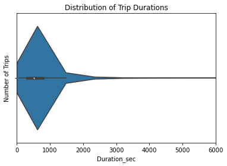

> it looks like that Trip duration is mostly centered on values which are less than 1000 seconds .

## (Distribution of Start Time Hours )

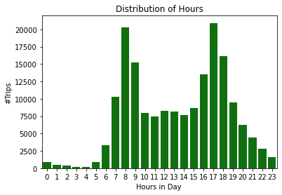

> it's looks like most biker start riding from 8 Am and 5 PM in day

## (Distribution of Days of Week )

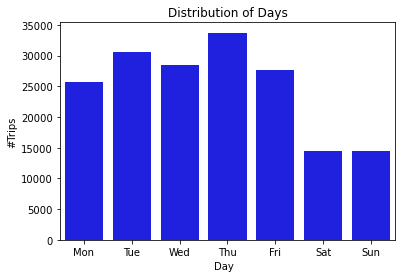

> it looks Tuesday and thursday has most bikers in these two days than other days in weeks

## (Distribution of member gender )

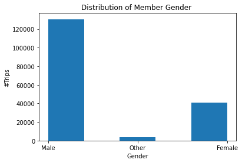

> most Bikers are Males

## (Relation between age and Trip Duration )

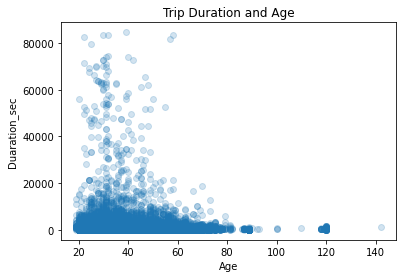

> it looks like ages between 20 and 60 is more to take more time than older people

## (Relation between Day and Trip Duration )

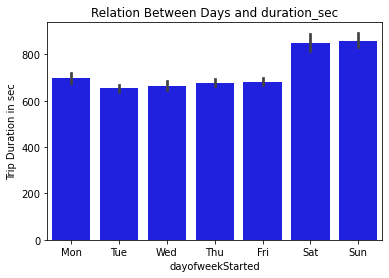

## (Relation between Day and user_type )

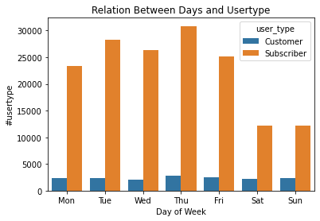

> it looks like Subscriber has more usage than customer over all

## (Relation between Trip Duration ,user type, and Age )

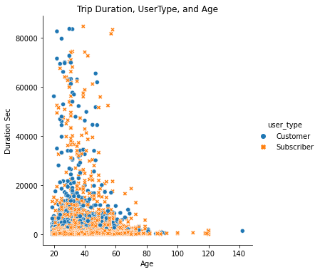

> it looks like that both subscriber and customer has the same trend in the age but it's observed that subscribers the trip duration is higher than customer for older age .